# PROBLEM STATEMENT

Recent years, the employee performance indexes are not healthy and this is becoming a growing concerns among the top management. There has been increased escalations on service delivery and client satisfaction levels came down by 8 percentage points.

#### BASED ON GIVEN FEATURE OF DATASET WE NEED TO PREDICT THE PERFOMANCE RATING OF EMPLOYEE

# EXPLORATORY DATA ANALYSIS SUMMARY:

- Basic checks of data
- Examine the data
- CHECK MISSING VALUE
- CHECKING DUPLICATES
- CHECK OUTLIERS
- Department Wise performance
- To analyse on performance as per department & environment satisfaction wise
- Analysis of performance rating employee role wise
- Analysis experience wise
- Employee last salary hike percent as Department wise
- Employee Work life balance
- TOP 3 FACTOR AFFECTING TO THE EMPLOYEE PERFORMANCE
- UNIVARIATE ANALYSIS:
  1. Age
  2. Employee Hourly Rate
  3. Total Work Experience In Year,
  4. Experience Years At This Company
- USE SUBPLOT TO PLOTS MULTIPLE FEATURE:

Gender', 'EducationBackground', 'MaritalStatus', 'BusinessTravelFrequency', 'DistanceFromHome', 'EmpEducationLevel', 'EmpEnvironmentSatisfaction', 'EmpJobInvolvement', 'EmpJobLevel', 'EmpJobSatisfaction', 'NumCompaniesWorked', 'OverTime', 'EmpLastSalaryHikePercent', 'EmpRelationshipSatisfaction', 'EmpWorkLifeBalance' , 'ExperienceYearsInCurrentRole', 'YearsWithCurrManager', 'Attrition', 'PerformanceRating'

# IMPORTING NECESSARY LIBRARY:

```python
import pandas as pd
import numpy as np
import matplotlib.pyplot as plt
%matplotlib inline
import seaborn as sns
import plotly.express as px
import plotly.io as pio
from scipy import stats
import warnings # Used to supressed the warnings
warnings.filterwarnings('ignore')
```

# LOAD DATA FOR EXPLOTARY DATA ANALYSIS

```python
df = pd.read_csv('/content/drive/MyDrive/INX_Future_Inc_Employee_Performance_CDS_Project2_Data_V1.8 2.csv')
```

## BASIC CHECKS OF DATA

```python
df.head()
```

|  | EmpNumber | Age | Gender | EducationBackground | MaritalStatus | EmpDepartment | EmpJobRole | BusinessTravelFrequency | DistanceFromHome | EmpEducationLevel | ... | EmpRelationshipSatisfaction | TotalWorkExperienceInYears | TrainingTimesLastYear | EmpWorkLifeBalance | ExperienceYearsAtThisCompany | ExperienceYearsInCurrentRole | YearsSinceLastPromotion | YearsWithCurrManager | Attrition | PerformanceRating |
| --- | --- | --- | --- | --- | --- | --- | --- | --- | --- | --- | --- | --- | --- | --- | --- | --- | --- | --- | --- | --- | --- |
| 0 | E1001000 | 32 | Male | Marketing | Single | Sales | Sales Executive | Travel_Rarely | 10 | 3 | ... | 4 | 10 | 2 | 2 | 10 | 7 | 0 | 8 | No | 3 |
| 1 | E1001006 | 47 | Male | Marketing | Single | Sales | Sales Executive | Travel_Rarely | 14 | 4 | ... | 4 | 20 | 2 | 3 | 7 | 7 | 1 | 7 | No | 3 |
| 2 | E1001007 | 40 | Male | Life Sciences | Married | Sales | Sales Executive | Travel_Frequently | 5 | 4 | ... | 3 | 20 | 2 | 3 | 18 | 13 | 1 | 12 | No | 4 |
| 3 | E1001009 | 41 | Male | Human Resources | Divorced | Human Resources | Manager | Travel_Rarely | 10 | 4 | ... | 2 | 23 | 2 | 2 | 21 | 6 | 12 | 6 | No | 3 |
| 4 | E1001010 | 60 | Male | Marketing | Single | Sales | Sales Executive | Travel_Rarely | 16 | 4 | ... | 4 | 10 | 1 | 3 | 2 | 2 | 2 | 2 | No | 3 |

5 rows × 28 columns

```python
df.tail()
```

|  | EmpNumber | Age | Gender | EducationBackground | MaritalStatus | EmpDepartment | EmpJobRole | BusinessTravelFrequency | DistanceFromHome | EmpEducationLevel | ... | EmpRelationshipSatisfaction | TotalWorkExperienceInYears | TrainingTimesLastYear | EmpWorkLifeBalance | ExperienceYearsAtThisCompany | ExperienceYearsInCurrentRole | YearsSinceLastPromotion | YearsWithCurrManager | Attrition | PerformanceRating |
| --- | --- | --- | --- | --- | --- | --- | --- | --- | --- | --- | --- | --- | --- | --- | --- | --- | --- | --- | --- | --- | --- |
| 1195 | E100992 | 27 | Female | Medical | Divorced | Sales | Sales Executive | Travel_Frequently | 3 | 1 | ... | 2 | 6 | 3 | 3 | 6 | 5 | 0 | 4 | No | 4 |
| 1196 | E100993 | 37 | Male | Life Sciences | Single | Development | Senior Developer | Travel_Rarely | 10 | 2 | ... | 1 | 4 | 2 | 3 | 1 | 0 | 0 | 0 | No | 3 |
| 1197 | E100994 | 50 | Male | Medical | Married | Development | Senior Developer | Travel_Rarely | 28 | 1 | ... | 3 | 20 | 3 | 3 | 20 | 8 | 3 | 8 | No | 3 |
| 1198 | E100995 | 34 | Female | Medical | Single | Data Science | Data Scientist | Travel_Rarely | 9 | 3 | ... | 2 | 9 | 3 | 4 | 8 | 7 | 7 | 7 | No | 3 |
| 1199 | E100998 | 24 | Female | Life Sciences | Single | Sales | Sales Executive | Travel_Rarely | 3 | 2 | ... | 1 | 4 | 3 | 3 | 2 | 2 | 2 | 0 | Yes | 2 |

5 rows × 28 columns

```python
df.columns
```

```
Index(['EmpNumber', 'Age', 'Gender', 'EducationBackground', 'MaritalStatus',
       'EmpDepartment', 'EmpJobRole', 'BusinessTravelFrequency',
       'DistanceFromHome', 'EmpEducationLevel', 'EmpEnvironmentSatisfaction',
       'EmpHourlyRate', 'EmpJobInvolvement', 'EmpJobLevel',
       'EmpJobSatisfaction', 'NumCompaniesWorked', 'OverTime',
       'EmpLastSalaryHikePercent', 'EmpRelationshipSatisfaction',
       'TotalWorkExperienceInYears', 'TrainingTimesLastYear',
       'EmpWorkLifeBalance', 'ExperienceYearsAtThisCompany',
       'ExperienceYearsInCurrentRole', 'YearsSinceLastPromotion',
       'YearsWithCurrManager', 'Attrition', 'PerformanceRating'],
      dtype='object')
```

```python
df.shape
```

```
(1200, 28)
```

- Dataset contain total 28 features with 1 unique feature and 1200 observation.

# EXAMINE THE DATA

```python
df.info()
```

```
<class 'pandas.core.frame.DataFrame'>
RangeIndex: 1200 entries, 0 to 1199
Data columns (total 28 columns):
 #   Column                        Non-Null Count  Dtype
---  ------                        --------------  -----
 0   EmpNumber                     1200 non-null   object
 1   Age                           1200 non-null   int64
 2   Gender                        1200 non-null   object
 3   EducationBackground           1200 non-null   object
 4   MaritalStatus                 1200 non-null   object
 5   EmpDepartment                 1200 non-null   object
 6   EmpJobRole                    1200 non-null   object
 7   BusinessTravelFrequency       1200 non-null   object
 8   DistanceFromHome              1200 non-null   int64
 9   EmpEducationLevel             1200 non-null   int64
```

[output cut: 20 more lines]

- In this data two type of data is available [int64, object]

# CHECK MISSING VALUE

```python
df.isnull().sum()
```

```
EmpNumber                       0
Age                             0
Gender                          0
EducationBackground             0
MaritalStatus                   0
EmpDepartment                   0
EmpJobRole                      0
BusinessTravelFrequency         0
DistanceFromHome                0
EmpEducationLevel               0
EmpEnvironmentSatisfaction      0
EmpHourlyRate                   0
EmpJobInvolvement               0
EmpJobLevel                     0
EmpJobSatisfaction              0
NumCompaniesWorked              0
OverTime                        0
EmpLastSalaryHikePercent        0
EmpRelationshipSatisfaction     0
TotalWorkExperienceInYears      0
TrainingTimesLastYear           0
EmpWorkLifeBalance              0
ExperienceYearsAtThisCompany    0
ExperienceYearsInCurrentRole    0
YearsSinceLastPromotion         0
YearsWithCurrManager            0
Attrition                       0
PerformanceRating               0
dtype: int64
```

- Their is no missing value present in the data.

# CHECKING DUPLICATES

```python
df.duplicated().sum()
```

```
0
```

- Their is no Duplicates is present in data

# CHECK OUTLIERS

```python
df.describe()
```

|  | Age | DistanceFromHome | EmpEducationLevel | EmpEnvironmentSatisfaction | EmpHourlyRate | EmpJobInvolvement | EmpJobLevel | EmpJobSatisfaction | NumCompaniesWorked | EmpLastSalaryHikePercent | EmpRelationshipSatisfaction | TotalWorkExperienceInYears | TrainingTimesLastYear | EmpWorkLifeBalance | ExperienceYearsAtThisCompany | ExperienceYearsInCurrentRole | YearsSinceLastPromotion | YearsWithCurrManager | PerformanceRating |
| --- | --- | --- | --- | --- | --- | --- | --- | --- | --- | --- | --- | --- | --- | --- | --- | --- | --- | --- | --- |
| count | 1200.000000 | 1200.000000 | 1200.00000 | 1200.000000 | 1200.000000 | 1200.000000 | 1200.000000 | 1200.000000 | 1200.000000 | 1200.000000 | 1200.000000 | 1200.000000 | 1200.000000 | 1200.000000 | 1200.000000 | 1200.000000 | 1200.000000 | 1200.000000 | 1200.000000 |
| mean | 36.918333 | 9.165833 | 2.89250 | 2.715833 | 65.981667 | 2.731667 | 2.067500 | 2.732500 | 2.665000 | 15.222500 | 2.725000 | 11.330000 | 2.785833 | 2.744167 | 7.077500 | 4.291667 | 2.194167 | 4.105000 | 2.948333 |
| std | 9.087289 | 8.176636 | 1.04412 | 1.090599 | 20.211302 | 0.707164 | 1.107836 | 1.100888 | 2.469384 | 3.625918 | 1.075642 | 7.797228 | 1.263446 | 0.699374 | 6.236899 | 3.613744 | 3.221560 | 3.541576 | 0.518866 |
| min | 18.000000 | 1.000000 | 1.00000 | 1.000000 | 30.000000 | 1.000000 | 1.000000 | 1.000000 | 0.000000 | 11.000000 | 1.000000 | 0.000000 | 0.000000 | 1.000000 | 0.000000 | 0.000000 | 0.000000 | 0.000000 | 2.000000 |
| 25% | 30.000000 | 2.000000 | 2.00000 | 2.000000 | 48.000000 | 2.000000 | 1.000000 | 2.000000 | 1.000000 | 12.000000 | 2.000000 | 6.000000 | 2.000000 | 2.000000 | 3.000000 | 2.000000 | 0.000000 | 2.000000 | 3.000000 |
| 50% | 36.000000 | 7.000000 | 3.00000 | 3.000000 | 66.000000 | 3.000000 | 2.000000 | 3.000000 | 2.000000 | 14.000000 | 3.000000 | 10.000000 | 3.000000 | 3.000000 | 5.000000 | 3.000000 | 1.000000 | 3.000000 | 3.000000 |
| 75% | 43.000000 | 14.000000 | 4.00000 | 4.000000 | 83.000000 | 3.000000 | 3.000000 | 4.000000 | 4.000000 | 18.000000 | 4.000000 | 15.000000 | 3.000000 | 3.000000 | 10.000000 | 7.000000 | 3.000000 | 7.000000 | 3.000000 |
| max | 60.000000 | 29.000000 | 5.00000 | 4.000000 | 100.000000 | 4.000000 | 5.000000 | 4.000000 | 9.000000 | 25.000000 | 4.000000 | 40.000000 | 6.000000 | 4.000000 | 40.000000 | 18.000000 | 15.000000 | 17.000000 | 4.000000 |

- In numerical features no constant column is present.

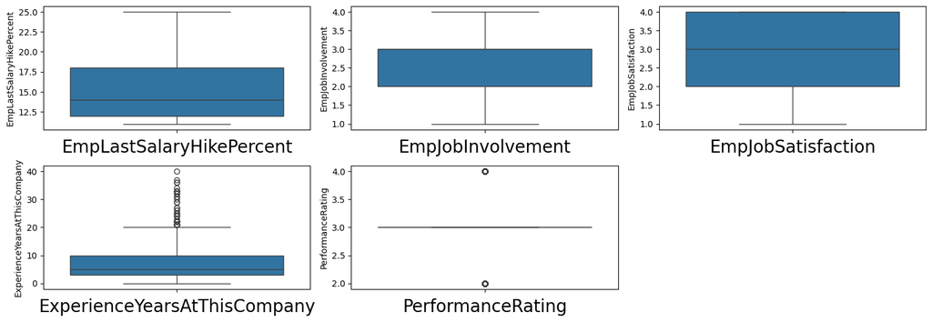

```python
outliers = df[['EmpLastSalaryHikePercent','EmpJobInvolvement','EmpJobSatisfaction','ExperienceYearsAtThisCompany','PerformanceRating']]

plt.figure(figsize=(15,10))
plotno = 1 # counter

for column in outliers: # iteration of columns / acessing the columns from count
    if plotno<=10:    # set the limit
        plt.subplot(4,3,plotno) # # plotting 7 graphs (3-rows,3-columns) ,plotnumber is for count
        sns.boxplot(outliers[column]) # Plotting box plots to detect the outlier
        plt.xlabel(column,fontsize=20)  # assigning name to x-axis and font size is 20
    plotno+=1 # counter increment
plt.tight_layout()
plt.show() # used to hide the storage loction
```

### Experience Years At This Company

```python
# Use iqr range because some skewed in data
iqr = stats.iqr(df['ExperienceYearsAtThisCompany'],interpolation='midpoint')
print("IQR:",iqr)

# Getting first & third quantile
Q1 = df['ExperienceYearsAtThisCompany'].quantile(0.25)
Q3 = df['ExperienceYearsAtThisCompany'].quantile(0.75)

# Get maximum and minimum limit
min_limit = Q1 - 1.5*iqr
print("Minimum limit:",min_limit)

max_limit = Q3 + 1.5*iqr
print("Maximum Limit:",max_limit)
```

```
IQR: 7.0
Minimum limit: -7.5
Maximum Limit: 20.5
```

```python
# Impute outlier
df.loc[df['ExperienceYearsAtThisCompany'] > max_limit,'ExperienceYearsAtThisCompany']=df['ExperienceYearsAtThisCompany'].median()
# Filtering the data
df.loc[df['ExperienceYearsAtThisCompany'] > max_limit]
```

|  | EmpNumber | Age | Gender | EducationBackground | MaritalStatus | EmpDepartment | EmpJobRole | BusinessTravelFrequency | DistanceFromHome | EmpEducationLevel | ... | EmpRelationshipSatisfaction | TotalWorkExperienceInYears | TrainingTimesLastYear | EmpWorkLifeBalance | ExperienceYearsAtThisCompany | ExperienceYearsInCurrentRole | YearsSinceLastPromotion | YearsWithCurrManager | Attrition | PerformanceRating |
| --- | --- | --- | --- | --- | --- | --- | --- | --- | --- | --- | --- | --- | --- | --- | --- | --- | --- | --- | --- | --- | --- |

0 rows × 28 columns

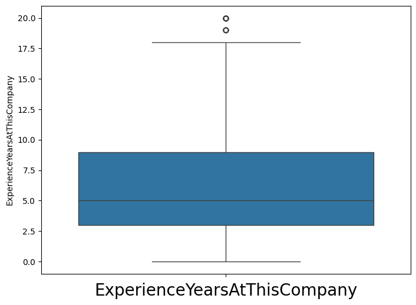

```python
out = df[['ExperienceYearsAtThisCompany']]

plt.figure(figsize=(20,10)) # defining canvas size
plotno = 1 # counter

for column in out: # iteration of columns / acessing the columns from count
    if plotno<=7:    # set the limit
        plt.subplot(2,3,plotno) # # plotting 7 graphs (3-rows,3-columns) ,plotnumber is for count
        sns.boxplot(out[column]) # Plotting box plots to detect the outlier
        plt.xlabel(column,fontsize=20)  # assigning name to x-axis and font size is 20
    plotno+=1 # counter increment
plt.tight_layout()
plt.show() # used to hide the storage loction
```

## 1. DEPARTMENT WISE PERFORMANCE RATING

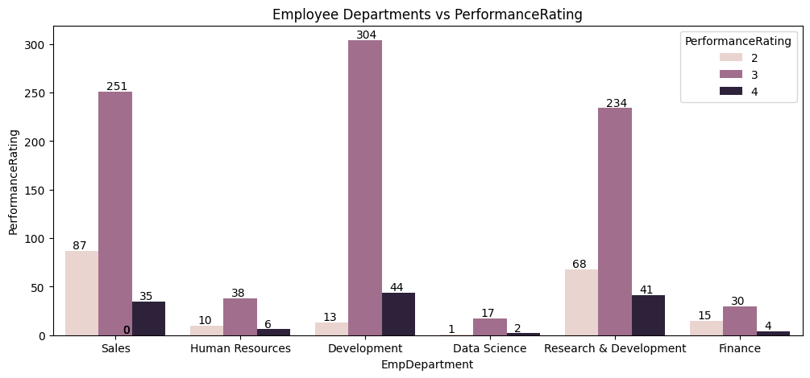

```python
plt.figure(figsize =(12,5))
ax =sns.countplot(x = 'EmpDepartment', data=df, hue =df.PerformanceRating)
for i in ax.patches:
    ax.annotate('{:.0f}'.format(i.get_height()), (i.get_x()+0.06, i.get_height()+2))
plt.title('Employee Departments vs PerformanceRating')
plt.xlabel('EmpDepartment')
plt.ylabel('PerformanceRating')
plt.show()
```

## 2. So from the below data we got clear indication of those employees who have low performance, low job involvement and have less or equal to 2 years of experience.

```python
low = df.loc[(df['PerformanceRating']==2)& (df['Attrition'] == 'No') & (df['EmpJobInvolvement'] <= 2) & (df['ExperienceYearsAtThisCompany'] <= 2),
['EmpNumber','PerformanceRating','Attrition' ,'EmpJobInvolvement' ,'ExperienceYearsAtThisCompany'] ]
low
```

|  | EmpNumber | PerformanceRating | Attrition | EmpJobInvolvement | ExperienceYearsAtThisCompany |
| --- | --- | --- | --- | --- | --- |
| 165 | E1001300 | 2 | No | 2 | 2 |
| 182 | E1001322 | 2 | No | 2 | 2 |
| 605 | E1002079 | 2 | No | 2 | 2 |
| 728 | E1002291 | 2 | No | 2 | 2 |
| 878 | E100461 | 2 | No | 2 | 2 |
| 1023 | E100702 | 2 | No | 2 | 2 |

- those 6 non performing employees can be penalized or given final warning for their performance.

## 3 .To analyse on performance as per department & environment satisfaction wise

```python
table = df.pivot_table(index ='EmpDepartment' , values = 'EmpEnvironmentSatisfaction' , columns ='PerformanceRating', aggfunc = 'mean')
table
```

| PerformanceRating EmpDepartment | 2 | 3 | 4 |
| --- | --- | --- | --- |
| Data Science | 1.000000 | 3.058824 | 3.000000 |
| Development | 1.461538 | 2.726974 | 2.954545 |
| Finance | 1.600000 | 3.333333 | 3.750000 |
| Human Resources | 1.600000 | 2.842105 | 3.000000 |
| Research & Development | 1.602941 | 3.038462 | 3.219512 |
| Sales | 1.586207 | 2.968127 | 3.028571 |

# Performance rating vs Environment satisfaction

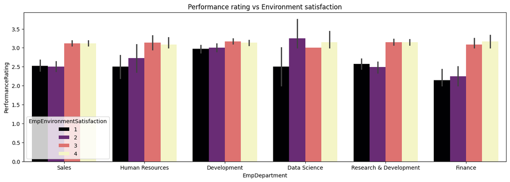

```python
plt.subplots(figsize = (16,5))
bar = sns.barplot(x = 'EmpDepartment', y = 'PerformanceRating', hue = 'EmpEnvironmentSatisfaction',data = df , palette = 'magma').set(title = "Performance rating vs Environment satisfaction")
```

- We can see that when environment satisfaction is low, performance is low.

## 4. Analysis of performance rating employee role wise

```
([0, 1, 2, 3, 4, 5, 6, 7, 8, 9, 10, 11, 12, 13, 14, 15, 16, 17, 18],
 [Text(0, 0, 'Sales Executive'),
```

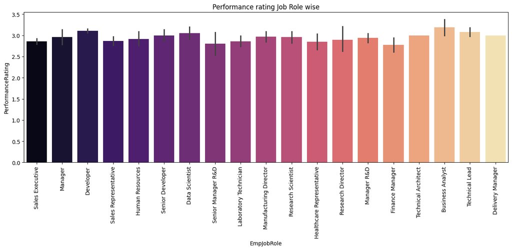

```python
plt.subplots(figsize = (16, 5))
bar = sns.barplot(y ='PerformanceRating',x = 'EmpJobRole', data = df, palette = 'magma').set(title = 'Performance rating Job Role wise')
plt.xticks(rotation=90)
```

## 5. Analysis experience wise

```
[Text(0.5, 1.0, 'Performance rating Experience wise')]
```

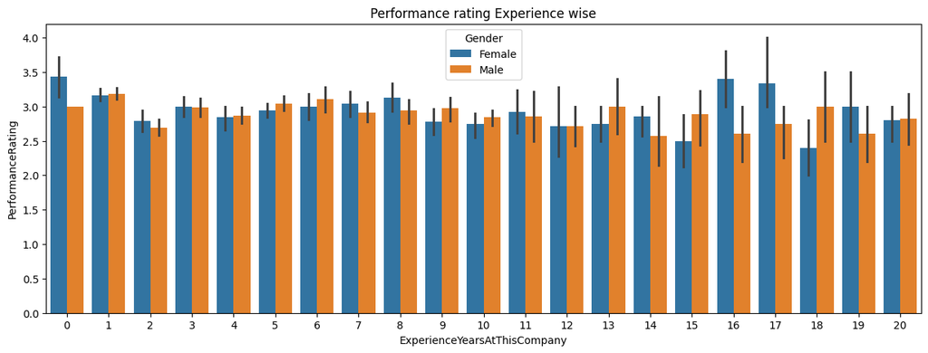

```python
plt.subplots(figsize =(15,5))
bar = sns.barplot(x = 'ExperienceYearsAtThisCompany', y = 'PerformanceRating', data = df ,hue ='Gender' )
bar.set(title = 'Performance rating Experience wise')
```

## 6. Employee last salary hike percent as Department wise

```python
pd.crosstab(df['EmpLastSalaryHikePercent'],df['EmpDepartment'], margins=True)
```

| EmpDepartment EmpLastSalaryHikePercent | Data Science | Development | Finance | Human Resources | Research & Development | Sales | All |
| --- | --- | --- | --- | --- | --- | --- | --- |
| 11 | 2 | 50 | 5 | 13 | 46 | 53 | 169 |
| 12 | 0 | 49 | 7 | 5 | 44 | 50 | 155 |
| 13 | 2 | 57 | 5 | 7 | 48 | 49 | 168 |
| 14 | 3 | 44 | 6 | 5 | 55 | 59 | 172 |
| 15 | 0 | 25 | 6 | 6 | 19 | 26 | 82 |
| 16 | 3 | 20 | 3 | 3 | 18 | 21 | 68 |
| 17 | 3 | 20 | 6 | 3 | 21 | 14 | 67 |
| 18 | 0 | 24 | 1 | 3 | 19 | 26 | 73 |
| 19 | 4 | 16 | 4 | 2 | 15 | 22 | 63 |
| 20 | 1 | 15 | 2 | 0 | 21 | 11 | 50 |
| 21 | 1 | 10 | 2 | 4 | 4 | 13 | 34 |
| 22 | 0 | 14 | 0 | 2 | 16 | 15 | 47 |
| 23 | 1 | 6 | 0 | 1 | 7 | 6 | 21 |
| 24 | 0 | 8 | 1 | 0 | 4 | 5 | 18 |
| 25 | 0 | 3 | 1 | 0 | 6 | 3 | 13 |
| All | 20 | 361 | 49 | 54 | 343 | 373 | 1200 |

## 7. Employee Work life balance

```python
pd.crosstab(df['EmpWorkLifeBalance'],df['PerformanceRating'],margins=True)
```

| PerformanceRating EmpWorkLifeBalance | 2 | 3 | 4 | All |
| --- | --- | --- | --- | --- |
| 1 | 16 | 48 | 0 | 64 |
| 2 | 51 | 216 | 27 | 294 |
| 3 | 115 | 533 | 79 | 727 |
| 4 | 12 | 77 | 26 | 115 |
| All | 194 | 874 | 132 | 1200 |

# TOP 3 FACTOR AFFECTING TO THE EMPLOYEE PERFORMANCE

**From visualisation file we get the top 3 factor affecting to the employee performance**

1. Emp Environment Satisfaction
2. Emp Last Salary Hike Percent
3. Emp Work Life Balance

From above visualization, we can clearly observe that Salary hike, Environment satisfaction,Job satisfaction, Employee experience marked great impact on Performance ratings. So, from management side, they need to look after in these matters to increase the employees performance

**Observation:**

**1.Employee Enviroment satisfaction:**

- Maximum Number of Employees Performance Rating belongs to EmpEnvironmentSatisfaction Level 3 & Level 4, It contains 367 & 361.

**2.Employee last salary hike percent:**

- More Number of Employees whose salary hike percentage belongs to 11-19 % are getting 2 & 3 performance rating Maximum time. Employees whose salary hike percentage is in between 20-22%, There performance rating is 4

**3.Employee work life balance:**

- In EmpWorkLifeBalance, level 3 is showing high Performance Rating of employees

# UNIVARIATE ANALYSIS

**PLOTS USED:**

**continuous features**

histogram: A histogram is a bar graph-like representation of data that buckets a range of classes into columns along the horizontal x-axis. The vertical y-axis represents the number count or percentage of occurrences in the data for each column.

# 1.Age

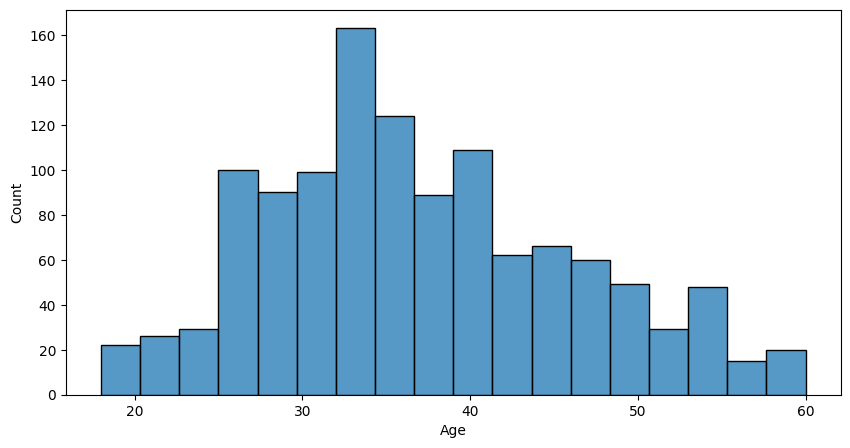

```python
plt.figure(figsize = (10,5))
sns.histplot(x='Age',data= df)
plt.xlabel('Age')
plt.show()
```

**Observation:**

The range of age between 18 to 60, most of the employee age between 25 to 40.

# 2.Employee Hourly Rate

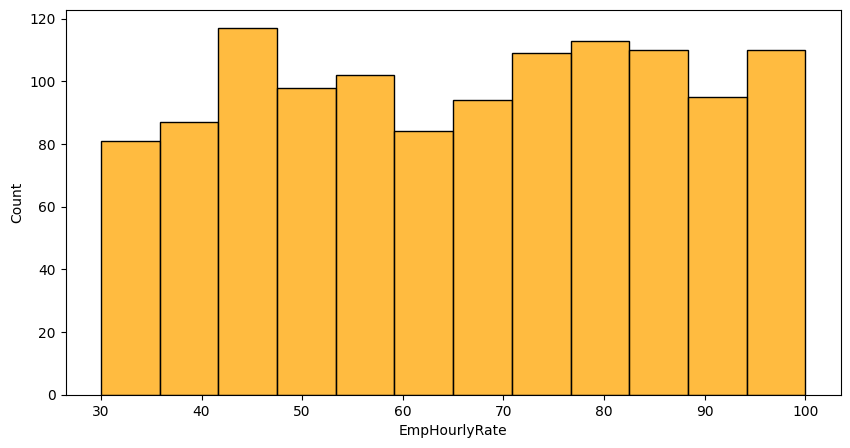

```python
plt.figure(figsize = (10,5))
sns.histplot(x ='EmpHourlyRate', data = df ,color ='orange')
plt.xlabel('EmpHourlyRate')
plt.show()
```

**Observation:** The range of employee hourly rate between 30 to 100, most of the employee hourly rate is 45.

# 3.Total Work Experience In Year

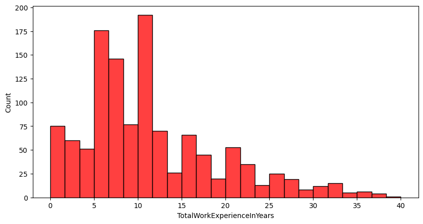

```python
plt.figure(figsize = (10,5))
sns.histplot(x = 'TotalWorkExperienceInYears' , data = df, color ='red',)
plt.xlabel('TotalWorkExperienceInYears')
plt.show()
```

**Observation:** Work experiance range between 0 to 40,Most of the employee experiance ranges between 5 to 10.

# 4.Experience Years At This Company

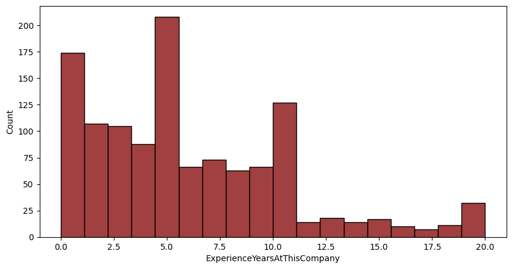

```python
plt.figure(figsize = (10,5))
sns.histplot(x='ExperienceYearsAtThisCompany', data =df , color ='maroon', )
plt.xlabel('ExperienceYearsAtThisCompany')
plt.show()
```

## USE SUBPLOT TO PLOTS MULTIPLE FEATURE

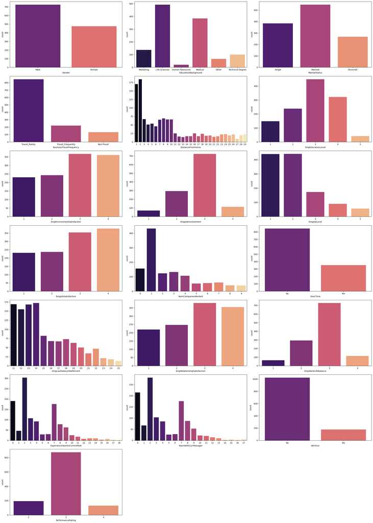

```python
data = df[['Gender', 'EducationBackground', 'MaritalStatus','BusinessTravelFrequency','DistanceFromHome',
              'EmpEducationLevel', 'EmpEnvironmentSatisfaction','EmpJobInvolvement', 'EmpJobLevel',
              'EmpJobSatisfaction', 'NumCompaniesWorked', 'OverTime','EmpLastSalaryHikePercent', 'EmpRelationshipSatisfaction','EmpWorkLifeBalance',
               'ExperienceYearsInCurrentRole', 'YearsWithCurrManager', 'Attrition',
               'PerformanceRating']]
plt.figure(figsize=(25,35))
plotno = 1 # counter
for column in data: # iteration of columns / acessing the columns from count
    if plotno<=20:    # set the limit
        plt.subplot(7,3,plotno) # # plotting 12 graphs (4-rows,3-columns) ,plotnumber is for count
        sns.countplot(x=data[column],palette = 'magma')
        plt.xlabel(column)
    plotno+=1 # counter increment
plt.tight_layout()
plt.show()
```

**Observation:**

## 5. Gender:

- Most of the male present in the comapany

## 6. Education Background:

- most of the education background of employee is Life science and medical, as well as marketing eduaction background employee is more than 100.
- other eduacation background employee is less than 100.

## 7. MaritalStatus:

- Most of the employee is married as well as less than 400 employee is single.
- less than 300 employee mariatal status is divorced.

## 9. Distance From Home:

- The range of distance between home to comapny is 1 to 29.
- Maximum no of employee home to company distance is less than 10.

## 10. Educational Level:

- Total range of educational level is 1 to 5,Maximum no of employee education level is 3 & 4.
- 2 education level employee is less than 250 and remianing 1 & 5 education level employee is less than 150.

## 11.Employee Environment Satisfaction:

- Most of the employee Statisfaction is 3 & 4
- 1 & 2 enviroment satisfaction employee less than 250

## 13.Employee Job Level:

- The range of employee job kevel is 1 to 5,most of the employee job level is 1 & 2.
- Minimum no of job level is 5, as well as 3 & 4 job level employee is less than 180.

## 14.Employee Job Satisfaction:

- Most of the employee job satisfaction is 3 & 4 score as well as 1 & 2 score jon satisfaction employee is less than 250.

## 15.Number Companies Worked:

- Maximum no of employee work with only one company.
- less no of employee work in more than 5 companies.

## 16.Overtime:

- Most no of employee on doing over time and less than 350 employee doing overtime in company.

## 18. Employee Relationship Satisfaction:

- The range of employee relationship satisfaction is 1 to 4,Most of the relation satisfaction is 3 & 4 as well as less than 250 employee with 1 & 2 relationship satisfaction.

## 20. Experiance In Current Role:

- Maximum current role experiance of employee is 18.
- Most of the employee have 2 years of expriance in current role then 7 year of experiance employee is less than 180
- less than 200 employee have not current role experiance.

## 21. Years With Current Manager:

- Most employee have 2 years with current manager and minimum 16 years with current manager.
- The range in between 0 to 17 and less than 180 employee has 7 years with current manager.

## 22. Attrition:

- Maximum no of employee has not leave the company and less than 200 employee has going to leave the company.

## 23. Performance Rating:

- The range of performance rating is 2 to 4, most of the employee have 3 performance ranting and less performance rating is 4.
- less than 200 employee has 2 performance rating.